# hw02_gapminder

Martin

# Exercise 1.1 - Selected Countries in 1970s

Gapminder Data for Brazil, Canada, and Japan

| country | continent | year | lifeExp | pop | gdpPercap |
| --- | --- | --- | --- | --- | --- |
| Brazil | Americas | 1972 | 59.504 | 100840058 | 4985.711 |
| Brazil | Americas | 1977 | 61.489 | 114313951 | 6660.119 |
| Canada | Americas | 1972 | 72.880 | 22284500 | 18970.571 |
| Canada | Americas | 1977 | 74.210 | 23796400 | 22090.883 |
| Japan | Asia | 1972 | 73.420 | 107188273 | 14778.786 |
| Japan | Asia | 1977 | 75.380 | 113872473 | 16610.377 |

# Exercise 1.2 - Selected Countries and GDP Per Capita in the 70s

GDP per Capita in the 1970s

| country | gdpPercap |
| --- | --- |
| Brazil | 4985.711 |
| Brazil | 6660.119 |
| Canada | 18970.571 |
| Canada | 22090.883 |
| Japan | 14778.786 |
| Japan | 16610.377 |

# Exercise 1.3 - Drop in Life Expectancy

|  | country | continent | year | lifeExp | pop | gdpPercap | increaseinlifeExp |
| --- | --- | --- | --- | --- | --- | --- | --- |
| 1 | Rwanda | Africa | 1992 | 23.599 | 7290203 | 737.0685949 | -20.421 |
| 2 | Zimbabwe | Africa | 1997 | 46.809 | 11404948 | 792.4499603 | -13.568 |
| 3 | Lesotho | Africa | 2002 | 44.593 | 2046772 | 1275.184575 | -10.965 |
| 4 | Swaziland | Africa | 2002 | 43.869 | 1130269 | 4128.116943 | -10.42 |
| 5 | Botswana | Africa | 1997 | 52.556 | 1536536 | 8647.142313 | -10.189 |
| 6 | Cambodia | Asia | 1977 | 31.22 | 6978607 | 524.9721832 | -9.097 |
| 7 | Namibia | Africa | 2002 | 51.479 | 1972153 | 4072.324751 | -7.43 |
| 8 | South Africa | Africa | 2002 | 53.365 | 44433622 | 7710.946444 | -6.871 |
| 9 | Zimbabwe | Africa | 2002 | 39.989 | 11926563 | 672.0386227 | -6.82 |
| 10 | China | Asia | 1962 | 44.50136 | 665770000 | 487.6740183 | -6.0476 |

[output cut: 92 more lines]

# Exercise 1.4 - Max GDP Per Capita for Each Country

|  | country | maxgdpPercap |
| --- | --- | --- |
| 1 | Afghanistan | 978.0114388 |
| 2 | Albania | 5937.029526 |
| 3 | Algeria | 6223.367465 |
| 4 | Angola | 5522.776375 |
| 5 | Argentina | 12779.37964 |
| 6 | Australia | 34435.36744 |
| 7 | Austria | 36126.4927 |
| 8 | Bahrain | 29796.04834 |
| 9 | Bangladesh | 1391.253792 |
| 10 | Belgium | 33692.60508 |

[output cut: 132 more lines]

# Exercise 1.5 - Canada Life Expectancy vs GDP Per Capita

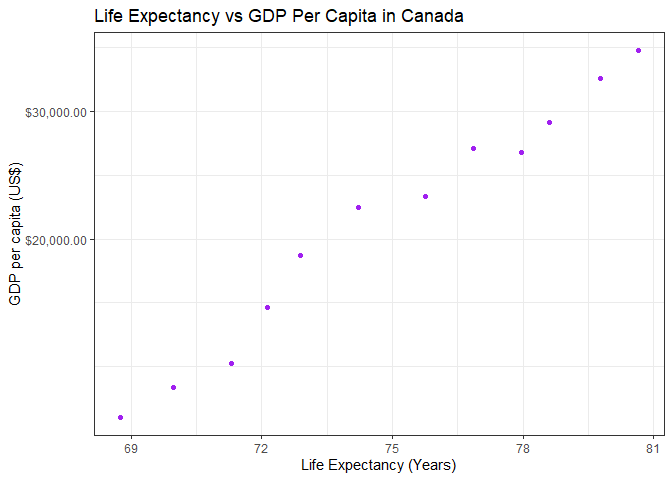

# Exercise 2: Exploring a Quantitative Variable (Population)

|  | country | min_pop | max_pop | mean_pop | median_pop | sd_pop |
| --- | --- | --- | --- | --- | --- | --- |
| 1 | Afghanistan | 8425333 | 31889923 | 15823715.4166667 | 13473708.5 | 7114583.47431877 |
| 2 | Albania | 1282697 | 3600523 | 2580249.16666667 | 2644572.5 | 828585.541696081 |
| 3 | Algeria | 9279525 | 33333216 | 19875406.1666667 | 18593278.5 | 8613355.34416447 |
| 4 | Angola | 4232095 | 12420476 | 7309390.08333333 | 6589529.5 | 2672280.58533307 |
| 5 | Argentina | 17876956 | 40301927 | 28602239.9166667 | 28162601 | 7546608.98902828 |
| 6 | Australia | 8691212 | 20434176 | 14649312.5 | 14629150 | 3915202.96477682 |
| 7 | Austria | 6927772 | 8199783 | 7583298.41666667 | 7571521.5 | 437659.982043233 |
| 8 | Bahrain | 120447 | 708573 | 373913.166666667 | 337688.5 | 210893.261610458 |
| 9 | Bangladesh | 46886859 | 150448339 | 90755395.3333333 | 86751356 | 34711660.6898279 |
| 10 | Belgium | 8730405 | 10392226 | 9725118.66666667 | 9839051.5 | 520635.932944481 |

[output cut: 132 more lines]

# Exercise 2: Exploring a Categorical Variable (Continent)

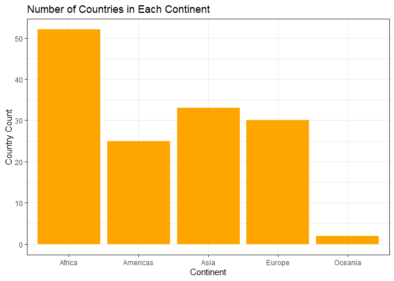

No. of Countries in Each Continent

| continent | n |
| --- | --- |
| Africa | 52 |
| Americas | 25 |
| Asia | 33 |
| Europe | 30 |
| Oceania | 2 |

# Exercise 3: Scatterplot Using mtcars Data Set

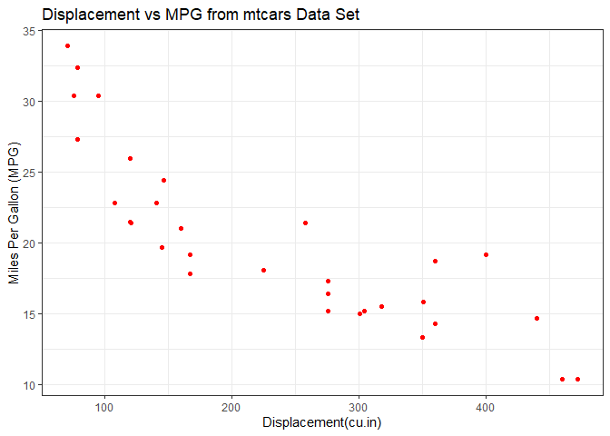

# Exercise 3: Bar Graph Using mtcars Data Set

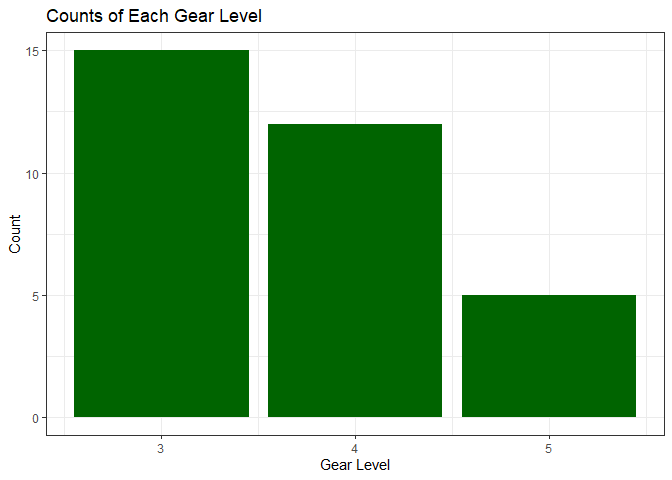

# Recycling

```r
filter(gapminder, country == c("Rwanda", "Afghanistan")) %>%
  kable(., format = "html", caption = "Gapminder Data for Rwanda and Afghanistan")%>%
  kable_styling()
```

Gapminder Data for Rwanda and Afghanistan

| country | continent | year | lifeExp | pop | gdpPercap |
| --- | --- | --- | --- | --- | --- |
| Afghanistan | Asia | 1957 | 30.332 | 9240934 | 820.8530 |
| Afghanistan | Asia | 1967 | 34.020 | 11537966 | 836.1971 |
| Afghanistan | Asia | 1977 | 38.438 | 14880372 | 786.1134 |
| Afghanistan | Asia | 1987 | 40.822 | 13867957 | 852.3959 |
| Afghanistan | Asia | 1997 | 41.763 | 22227415 | 635.3414 |
| Afghanistan | Asia | 2007 | 43.828 | 31889923 | 974.5803 |
| Rwanda | Africa | 1952 | 40.000 | 2534927 | 493.3239 |
| Rwanda | Africa | 1962 | 43.000 | 3051242 | 597.4731 |
| Rwanda | Africa | 1972 | 44.600 | 3992121 | 590.5807 |
| Rwanda | Africa | 1982 | 46.218 | 5507565 | 881.5706 |
| Rwanda | Africa | 1992 | 23.599 | 7290203 | 737.0686 |
| Rwanda | Africa | 2002 | 43.413 | 7852401 | 785.6538 |

The result produced was not what the author intended. Instead of filtering all the rows with “Rwanda” and “Afghanistan”, they only pulled out 12 rows. 6 rows for “Afghanistan” and 6 rows for “Rwanda”. This is incorrect because if we look at the year column, we can see that it does not capture all the data. The gapminder data set contains data for each country from the year 1952 until 2007 in intervals of 5 and each country should have 12 observations (code below). We can see from the output of their code that it does not produce 12 rows for both “Afghanistan” and “Rwanda.” In addition, it does not produce all the years correctly for both countries. For example, “Afghanistan” is missing the year 1952. Therefore, based on the number of rows printed and the missing data in the year column, the author’s code is not outputting what they intended.

```r
unique(gapminder$year)
```

```
##  [1] 1952 1957 1962 1967 1972 1977 1982 1987 1992 1997 2002 2007
```

```r
gapminder %>%
  count(country)
```

```
## # A tibble: 142 x 2
##    country         n
##    <fct>       <int>
##  1 Afghanistan    12
##  2 Albania        12
##  3 Algeria        12
##  4 Angola         12
##  5 Argentina      12
##  6 Australia      12
##  7 Austria        12
##  8 Bahrain        12
##  9 Bangladesh     12
## 10 Belgium        12
## # ... with 132 more rows
```

What is happening here is that since the “==” operator is being used to test equality on vectors of unequal length, the smaller vector which is “Rwanda” and “Afghanistan,” is being recycled until it is the same length as the country vector which happens to be about 1704 rows of data (code below).

```r
nrow(gapminder)
```

```
## [1] 1704
```

I suspect that R is returning all the **odd numbered rows** which happen to be the **even numbered years** for “Rwanda” and all the **even numbered rows** which happen to be the **odd numbered years** for “Afghanistan” which is why it only outputs 6 rows for both countries. A possible explanation for this is perhaps because “Rwanda” is in the “1” position, it is an odd number, and thus R looks for the first odd numbered row that contains “Rwanda.” Then going with this thought, “Afghanistan” is in the “2” position and R looks for the first even numbered that contains “Afghanistan.”

# My Fix

To fix the code, here is one proposed solution which outputs 24 rows. 12 for “Afghanistan” and 12 for “Rwanda” from 1952 to 2007 in intervals of 5.

```r
gapminder %>%
  filter(country == "Rwanda" | country == "Afghanistan") %>%
  DT::datatable()
```

|  | country | continent | year | lifeExp | pop | gdpPercap |
| --- | --- | --- | --- | --- | --- | --- |
| 1 | Afghanistan | Asia | 1952 | 28.801 | 8425333 | 779.4453145 |
| 2 | Afghanistan | Asia | 1957 | 30.332 | 9240934 | 820.8530296 |
| 3 | Afghanistan | Asia | 1962 | 31.997 | 10267083 | 853.10071 |
| 4 | Afghanistan | Asia | 1967 | 34.02 | 11537966 | 836.1971382 |
| 5 | Afghanistan | Asia | 1972 | 36.088 | 13079460 | 739.9811058 |
| 6 | Afghanistan | Asia | 1977 | 38.438 | 14880372 | 786.11336 |
| 7 | Afghanistan | Asia | 1982 | 39.854 | 12881816 | 978.0114388 |
| 8 | Afghanistan | Asia | 1987 | 40.822 | 13867957 | 852.3959448 |
| 9 | Afghanistan | Asia | 1992 | 41.674 | 16317921 | 649.3413952 |
| 10 | Afghanistan | Asia | 1997 | 41.763 | 22227415 | 635.341351 |

[output cut: 14 more lines]